# Weight Lifting Exercise - Quality Recognition

Michal Siwek

Thursday, November 20, 2015

## Summary

The aim of the report is to **model a particular barbell exercise** using accelerometer data so that the quality of the performance can be regonized. The model is bulit using **classification tree** method and its estimated out-of-sample **accuracy is 86%**.

Additionally the model is applied to predict the quality indicators for 20 observations in a supplied test set.

## Data

### Data collection

The data set contains readings from accelerometers located on the belt, forearm, arm, and dumbell of 6 participants performing the Unilateral Dumbbell Biceps Curl. Each of them performed a set of 10 repetition, in five different manners, called A-E, where A is the correct one, and B-E represents four different mistakes commonly made in the exercise. The data contains also participant name, date and time of the measurement, and time window indicators.

```r
train_file <- "./data/train.csv"
test_file <- "./data/test.csv"
training <- read.csv(train_file)
testing <- read.csv(test_file)
```

### The test set properties and preprocessing

The model is supposed to make predictions given a test set that contains only a subset of the training set variables.

```r
variables <- sapply(testing, function(x) sum(is.na(x)) == 0)  # selecting provided predictors
variables[1] <- F  # dropping column containing row numbers
```

Hence **all variables missing in the test set are dropped in the training set**. The time stamp variable is converted from factor to a proper date-time variable:

```r
frmt <- "%d/%m/%Y %H:%M"
training$cvtd_timestamp <- as.POSIXct(strptime(as.character(training$cvtd_timestamp), frmt, "GMT"))
testing$cvtd_timestamp <- as.POSIXct(strptime(as.character(testing$cvtd_timestamp), frmt, "GMT"))
```

The training set is split into two subsets: one for actual model training and one for out-of-sample error estimation.

```r
library(caret)
set.seed(123)
inTrain <- createDataPartition(training$classe, p = 0.7, list = F)
training1 <- training[inTrain, variables]
testing1 <- training[-inTrain, variables]
```

## Model

### Strategy

The model is aimed at **predicting the class of the activity given only the instantaneous measurments**. No data from any other time point (especially immediately preceding of following the prediction point) are taken into account. **All avaialble variables are used to train the model**, including special variables like participant names, time indicators etc. Using these special variables is acceptable given the content of the supplied test set.

As a result *this is more a task of estimating missing values for the “classe” column in the data gathered during the experiment, than an attempt to build a prediction model applicable to other experiments or real world situations*.

### Training algorithm

As the outcome variable is categorical I apply a **classification tree** algorithm, as provided by `rpart` package for R.

```r
library(rpart)
set.seed(123)
fit <- rpart(classe ~ ., data = training1, method = "class")
```

### Cross-validation

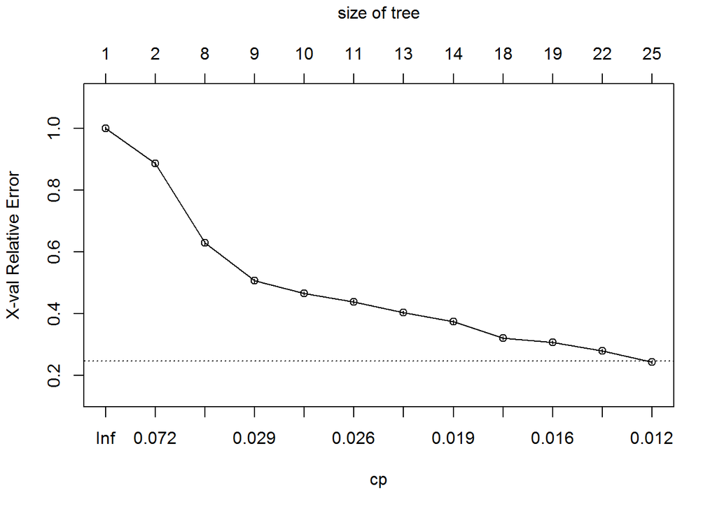

```r
plotcp(fit)
```

### Model ouput

The model produced following classification tree:

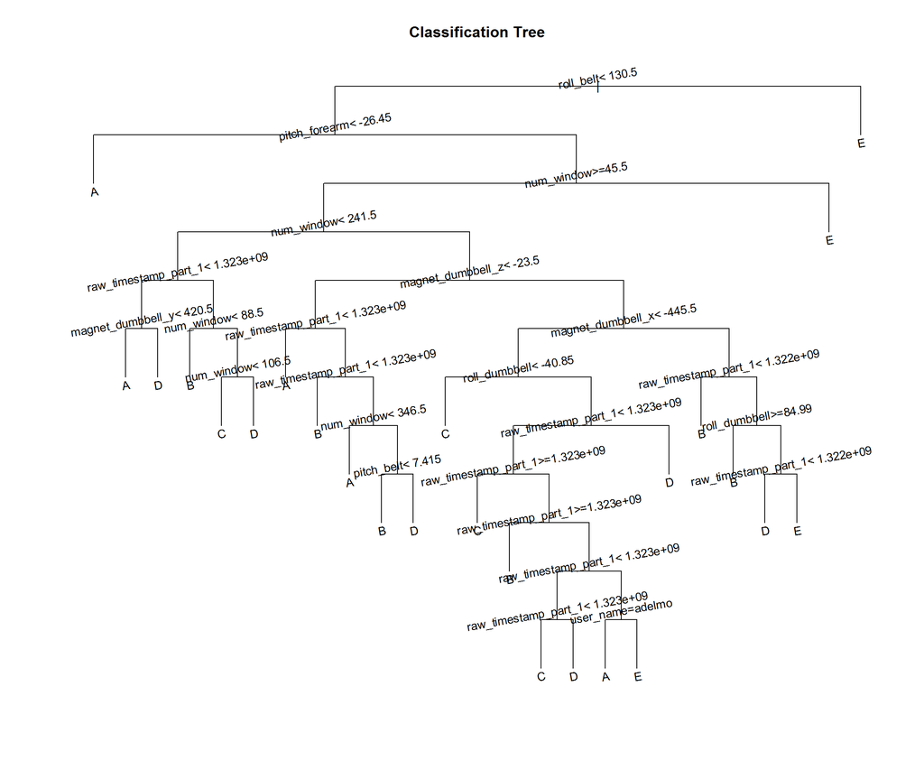

```r
plot(fit, uniform=TRUE, main="Classification Tree")
text(fit, srt = 10, cex = 0.9, minlength = 0)
```

### Expected out-of-sample error

```r
pred1 <- predict(fit, testing1, type = "class")
confusionMatrix(pred1, testing1$classe)
```

```
## Confusion Matrix and Statistics
##
##           Reference
## Prediction    A    B    C    D    E
##          A 1542   51    3    0    6
##          B   40  899   23    8   33
##          C   29   96  906  122   31
##          D   56   69   82  749   73
##          E    7   24   12   85  939
##
## Overall Statistics
##
##                Accuracy : 0.8556
##                  95% CI : (0.8463, 0.8645)
##     No Information Rate : 0.2845
##     P-Value [Acc > NIR] : < 2.2e-16
##
##                   Kappa : 0.8178
##  Mcnemar's Test P-Value : < 2.2e-16
##
## Statistics by Class:
##
##                      Class: A Class: B Class: C Class: D Class: E
## Sensitivity            0.9211   0.7893   0.8830   0.7770   0.8678
## Specificity            0.9858   0.9781   0.9428   0.9431   0.9733
## Pos Pred Value         0.9625   0.8963   0.7652   0.7279   0.8800
## Neg Pred Value         0.9692   0.9508   0.9745   0.9557   0.9703
## Prevalence             0.2845   0.1935   0.1743   0.1638   0.1839
## Detection Rate         0.2620   0.1528   0.1540   0.1273   0.1596
## Detection Prevalence   0.2722   0.1704   0.2012   0.1749   0.1813
## Balanced Accuracy      0.9534   0.8837   0.9129   0.8600   0.9206
```